# Draw links on the two different sides of a track

Zuguang Gu

2022-12-09

Links in circos plot can show relations between elements. In most cases, links are drawn in the most inside of the circle. However, separating links into two categories of those having short distances and those having large distances, and distinguishing them by putting them onto different sides of a track can sometimes improve the visualization. One typical example is to separate intergenic translocations and intragenic translocations of genes.

In the next example, I first generate positions for three genes (`A`, `B`, and `C`). Note for simplicity, the positions are not really bases.

```r
set.seed(123)
x = sort(runif(20))
df1 = data.frame(x1 = x[1:20 %% 2 == 0], x2 = x[1:20 %% 2 == 1])
df1 = cbind(gene = "A", df1)

x = sort(runif(10, max = 0.5))
df2 = data.frame(x1 = x[1:10 %% 2 == 0], x2 = x[1:10 %% 2 == 1])
df2 = cbind(gene = "B", df2)

x = sort(runif(30, max = 2))
df3 = data.frame(x1 = x[1:30 %% 2 == 0], x2 = x[1:30 %% 2 == 1])
df3 = cbind(gene = "C", df3)

df = rbind(df1, df2, df3)
df
```

```
##    gene         x1         x2
## 1     A 0.04555650 0.04205953
## 2     A 0.24608773 0.10292468
## 3     A 0.32792072 0.28757752
## 4     A 0.45333416 0.40897692
## 5     A 0.52810549 0.45661474
## 6     A 0.57263340 0.55143501
## 7     A 0.78830514 0.67757064
## 8     A 0.89241904 0.88301740
## 9     A 0.94046728 0.89982497
## 10    A 0.95683335 0.95450365
## 11    B 0.14457987 0.07355682
## 12    B 0.29707101 0.27203301
## 13    B 0.32785290 0.32025341
## 14    B 0.35426523 0.34640170
```

[output cut: 16 more lines]

I also generate the relations of translocation positions on the three genes. There are intragenic translocations where the translocation happens in the same gene, and intergenic translocations where the translocation happens in different genes.

```r
link = data.frame(
    gene1 = sample(c("A", "B", "C"), nrow(df), replace = TRUE),
    x1 = 0,
    gene2 = sample(c("A", "B", "C"), nrow(df), replace = TRUE),
    x2 = 0
)
for(i in seq_len(nrow(link))) {
    if(link$gene1[i] == "A") {
        link$x1[i] = runif(1)
    } else if(link$gene1[i] == "B") {
        link$x1[i] = runif(1, max = 0.5)
    } else if(link$gene1[i] == "C") {
        link$x1[i] = runif(1, max = 2)
    }

    if(link$gene2[i] == "A") {
        link$x2[i] = runif(1)
    } else if(link$gene2[i] == "B") {
        link$x2[i] = runif(1, max = 0.5)
    } else if(link$gene2[i] == "C") {
        link$x2[i] = runif(1, max = 2)
    }
}
link
```

```
##    gene1         x1 gene2         x2
## 1      A 0.78628155     C 1.95964383
## 2      C 0.87886307     C 0.62340440
## 3      A 0.40947495     A 0.01046711
## 4      B 0.09192476     B 0.42136466
## 5      A 0.23116178     A 0.23909996
## 6      A 0.07669117     B 0.12286184
## 7      C 1.46427041     A 0.84745317
## 8      A 0.49752727     C 0.77581806
## 9      B 0.12322450     C 0.22219292
## 10     A 0.38999444     B 0.28596766
## 11     C 0.43378553     C 0.88953600
## 12     A 0.21799067     A 0.50229956
## 13     C 0.70780914     B 0.32499258
## 14     B 0.18735698     B 0.17772269
```

[output cut: 16 more lines]

`df` and `link` are the basic inputs for making circular plot. With using **circlize**, `df` is used to initialize the layout and draw the gene models, and `link` is for drawing the translocations.

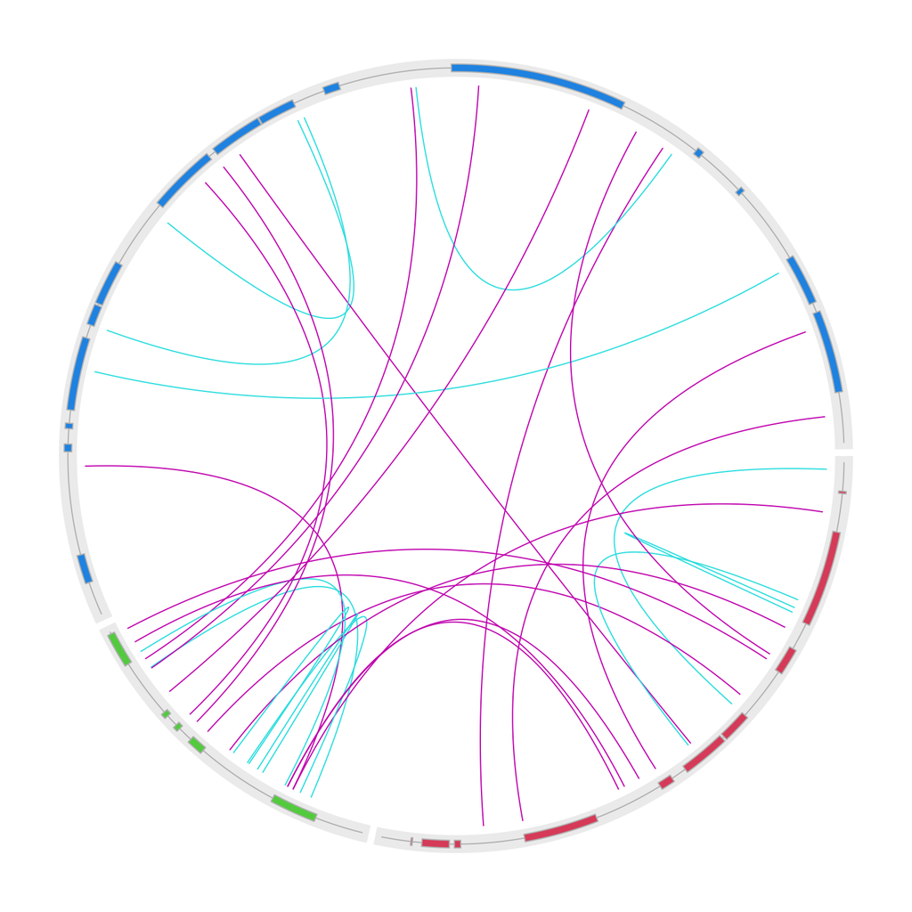

```r
library(circlize)
circos.initialize(c("A", "B", "C"), xlim = cbind(c(0, 0, 0), c(1, 0.5, 2)))

circos.track(ylim = c(0, 1), panel.fun = function(x, y) {
    tb = df[df[, 1] == CELL_META$sector.index, ]
    circos.lines(CELL_META$xlim, c(0.5, 0.5), col = "grey")
    circos.rect(tb[, 2], 0.1, tb[, 3], 0.9,
        col = 1+CELL_META$sector.numeric.index, border = "grey"
    )
}, track.height = mm_h(4), bg.border = NA, bg.col = "#EEEEEE")

for(i in seq_len(nrow(link))) {
    circos.link(link$gene1[i], link$x1[i], link$gene2[i], link$x2[i],
        col = ifelse(link$gene1[i] == link$gene2[i], 5, 6)
    )
}
```

```r
circos.clear()
```

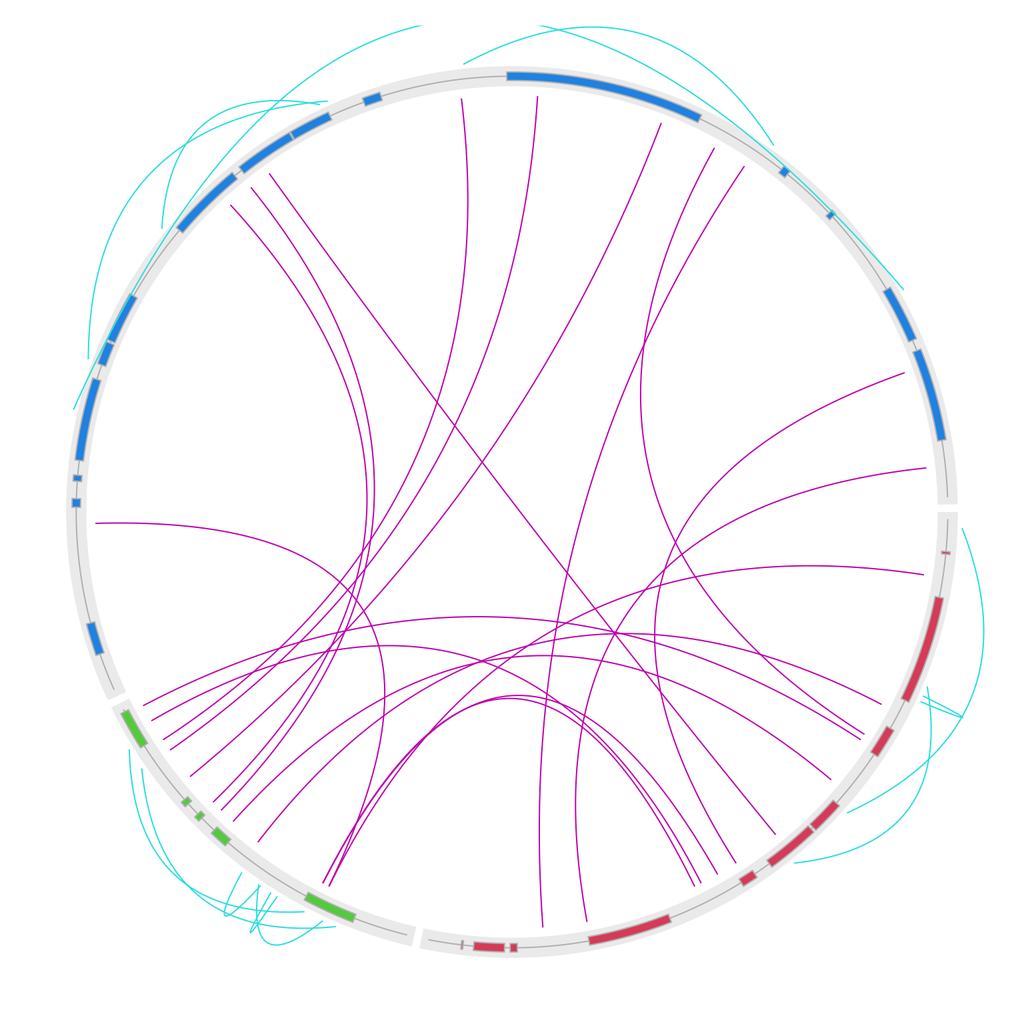

```r
circos.initialize(c("A", "B", "C"), xlim = cbind(c(0, 0, 0), c(1, 0.5, 2)))

circos.track(ylim = c(0, 1), panel.fun = function(x, y) {
    tb = df[df[, 1] == CELL_META$sector.index, ]
    circos.lines(CELL_META$xlim, c(0.5, 0.5), col = "grey")
    circos.rect(tb[, 2], 0.1, tb[, 3], 0.9, col = 1+CELL_META$sector.numeric.index, border = "grey")
}, track.height = mm_h(4), bg.border = NA, bg.col = "#EEEEEE")

for(i in seq_len(nrow(link))) {
    if(link$gene1[i] == link$gene2[i]) {
        circos.link(link$gene1[i], link$x1[i], link$gene2[i], link$x2[i], col = 5, h = -0.1, rou = 1)
    } else {
        circos.link(link$gene1[i], link$x1[i], link$gene2[i], link$x2[i], col = 6)
    }
}
```

```r
circos.clear()
```

One last thing, when the two ends of the intragenic link are too far, the default link might be too sharp. Here I also set `w = 0.1` to make outside links “fat”.

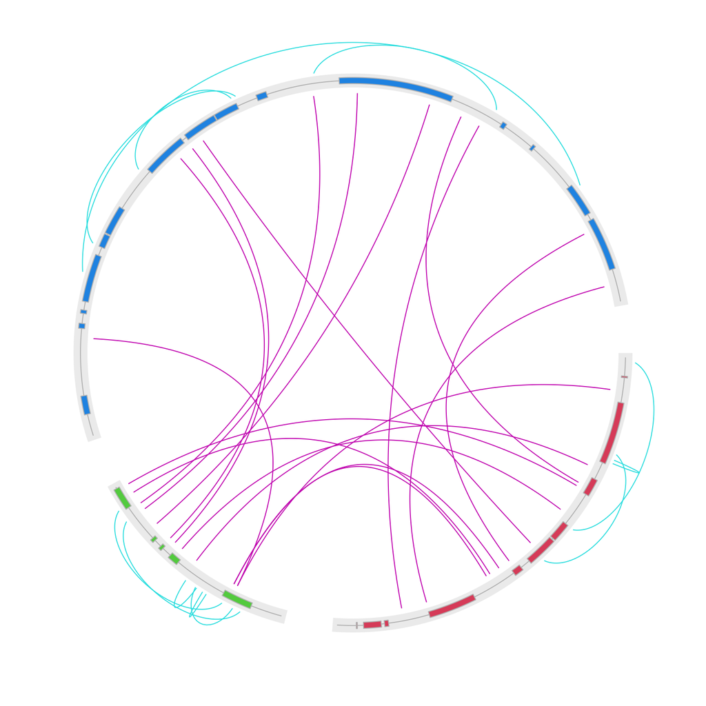

```r
circos.par(circle.margin = 0.1, gap.degree = 10)
circos.initialize(c("A", "B", "C"), xlim = cbind(c(0, 0, 0), c(1, 0.5, 2)))

circos.track(ylim = c(0, 1), panel.fun = function(x, y) {
    tb = df[df[, 1] == CELL_META$sector.index, ]
    circos.lines(CELL_META$xlim, c(0.5, 0.5), col = "grey")
    circos.rect(tb[, 2], 0.1, tb[, 3], 0.9, col = 1+CELL_META$sector.numeric.index, border = "grey")
}, track.height = mm_h(4), bg.border = NA, bg.col = "#EEEEEE")

for(i in seq_len(nrow(link))) {
    if(link$gene1[i] == link$gene2[i]) {
        circos.link(link$gene1[i], link$x1[i], link$gene2[i], link$x2[i], col = 5, h = -0.1, rou = 1, w = 0.1)
    } else {
        circos.link(link$gene1[i], link$x1[i], link$gene2[i], link$x2[i], col = 6)
    }
}
```

```r
circos.clear()
```

For the outside links, we may want the link to be shorter if its two ends are closer to each other. We can dynamically calculate the value of `h` according to the distance of a link’s two ends. Intuitively, we measure the distance by the degree difference of the two ends on the circle.

We first write a simple function which returns `h` based on the degree difference. in `get_h()`, if the degree difference is larger than 120 degrees, we let `h` take -0.15, and if the degree difference is smaller than 20 degrees, we let `h` take -0.05.

```r
get_h = function(degree_difference) {
    max_degree_difference = 120
    min_degree_difference = 20

    max_h = 0.15
    min_h = 0.05

    if(degree_difference >= max_degree_difference) {
        return(-max_h)
    }
    if(degree_difference <= min_degree_difference) {
        return(-min_h)
    }

    h = (degree_difference - min_degree_difference)/(max_degree_difference - min_degree_difference)*(max_h - min_h) + min_h
    -h
}
```

Next we write another function which calculates the degree difference. Note for simplicity, we only look at the link where its two ends are in the same sector. In `get_degree_difference()`, `get.cell.meta.data("cell.xlim", ...)` is used to get the data range on a specific sector, `get.cell.meta.data("xplot", ...)` is used to get the width of the sector measured by degree. Note since the data coordinates in sectors are always clockwise, `xplot[1]` is larger than `xplot[2]`.

```r
get_degree_difference = function(sector, x1, x2) {
    cell.xlim = get.cell.meta.data("cell.xlim", sector.index = sector, track.index = 1)
    xplot = get.cell.meta.data("xplot", sector.index = sector, track.index = 1)
    abs(x2 - x1)/(cell.xlim[2] - cell.xlim[1])*(xplot[1] - xplot[2])
}
```

With `get_h()` and `get_degree_difference()`, we can dynamically get the value of `h`

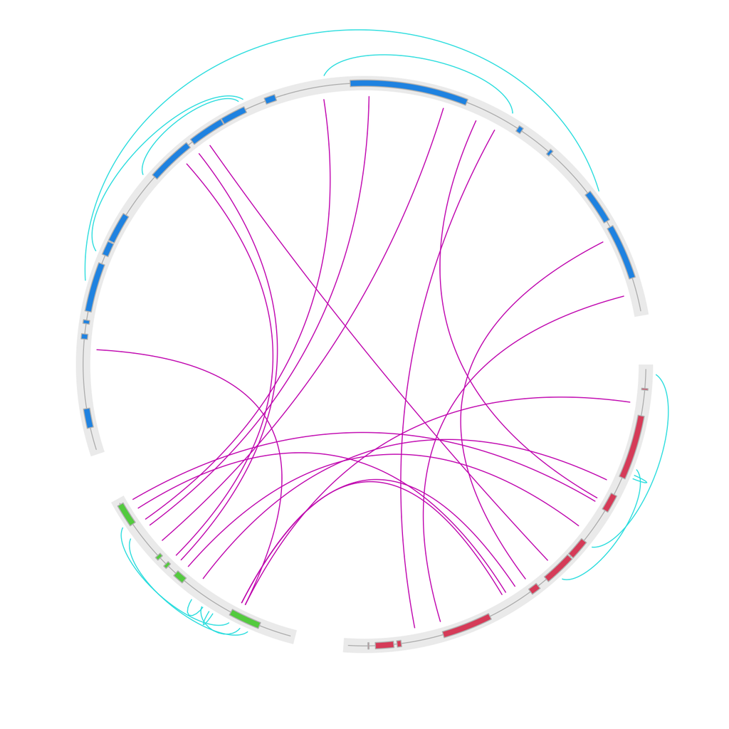

```r
circos.par(circle.margin = 0.1, gap.degree = 10)
circos.initialize(c("A", "B", "C"), xlim = cbind(c(0, 0, 0), c(1, 0.5, 2)))

circos.track(ylim = c(0, 1), panel.fun = function(x, y) {
    tb = df[df[, 1] == CELL_META$sector.index, ]
    circos.lines(CELL_META$xlim, c(0.5, 0.5), col = "grey")
    circos.rect(tb[, 2], 0.1, tb[, 3], 0.9, col = 1+CELL_META$sector.numeric.index, border = "grey")
}, track.height = mm_h(4), bg.border = NA, bg.col = "#EEEEEE")

for(i in seq_len(nrow(link))) {
    if(link$gene1[i] == link$gene2[i]) {
        degree_difference = get_degree_difference(link$gene1[i], link$x1[i], link$x2[i])
        h = get_h(degree_difference)
        circos.link(link$gene1[i], link$x1[i], link$gene2[i], link$x2[i], col = 5, h = h, rou = 1, w = 0.1)
    } else {
        circos.link(link$gene1[i], link$x1[i], link$gene2[i], link$x2[i], col = 6)
    }
}
```

```r
circos.clear()
```